# Marathon Training Plan Data Cleaning

Steve Newns

January 18, 2017

# *Initial Data Inspection*

## Strava Data File

First, I install packages

```r
#install.packages("stringr")  - for manipulating string values
#install.packages("tidyr")    - data cleansing
#install.packages("plyr")     - for renaming columns
#install.packages("lubridate")  - working with dates
```

Next, I load in the CSV file containing the Strava data file created by and downloaded from **VeloViewer.com** and check out the dataset.

```r
strava <- read.csv("strava.csv")
dim(strava)
```

```
## [1] 201  85
```

```r
head(strava)
```

```
##   Activity.Score             When Type                      Gear
## 1             50  11/20/2016 7:00  Run    Saucony Fastwitch Reds
## 2              0 11/19/2016 16:48  Run Hoka One One Clifton Reds
## 3              0 11/18/2016 17:22  Run Hoka One One Clifton Reds
## 4              0  11/17/2016 6:01  Run Hoka One One Clifton Reds
## 5              0 11/16/2016 12:07  Run Hoka One One Clifton Reds
## 6              0  11/15/2016 5:55  Run    Saucony Fastwitch Reds
##                                         Name Dist.mi Elv.ft Elapsed.Time
## 1 Oh My God So Freakin Windy Philly Marathon 43119.2  136.0        11443
## 2                               Recovery Run  4832.0   37.3         1571
## 3                               Recovery Run  8050.4   64.8         2616
## 4                                     GA Run 11270.1   50.8         3159
## 5                               Recovery Run  8058.0   36.8         2404
## 6                                     GA Run 12880.4   91.3         3638
##   Moving.Time Speed.mph Max.Speed.mph Pace..mi Max.Pace..mi Pace..100yds
```

[output cut: 90 more lines]

Okay, so there’s 201 activities in here, as well as a lot of columns (85 of them), with a majority of these columns probably not being useful for my purposes right now.

Now I want to explore the Garmin data as well before moving on the removing those unneccessary columns.

## Garmin Data Files

First, I load in the first of the CSV files containing the Garmin data created by and downloaded from **Garmin Connect** and check out the dataset.

```r
garmin1 <- read.csv("garmin1.csv")
dim(garmin1)
```

```
## [1] 21 16
```

```r
head(garmin1)
```

```
##            Activity.Name                     Start     Time Distance
## 1  Sea Isle City Running Wed, Aug 10, 2016 9:41 AM    23:31     3.00
## 2  Sea Isle City Running  Mon, Aug 8, 2016 7:31 AM  1:57:31    15.00
## 3  Sea Isle City Running  Sun, Aug 7, 2016 2:50 PM 30:04:00     4.01
## 4     Ocean City Running  Sat, Aug 6, 2016 6:18 AM  1:02:54     8.00
## 5       Chalfont Running  Fri, Aug 5, 2016 5:30 AM  1:30:35    12.00
## 6       Chalfont Running  Thu, Aug 4, 2016 5:11 AM 41:04:00     5.00
##   Elevation.Gain Avg.Speed.Avg.Pace. Max.Speed.Best.Pace. Avg.HR Max.HR
## 1             --                7:50                 6:13    134    151
## 2             13                7:50                 6:12    142    158
## 3              4                7:30                 5:11    149    160
## 4             --                7:52                 6:02    149    158
## 5            459                7:33                 5:05    148    158
## 6            224                8:12                 7:16    133    147
##   Calories sumStrokes Avg.Strokes Min.Strokes Avg.SWOLF Best.SWOLF
## 1      299         --          --          --        --         --
## 2    1,545         --          --          --        --         --
## 3      460         --          --          --        --         --
## 4      898         --          --          --        --         --
## 5    1,260         --          --          --        --         --
## 6      545         --          --          --        --         --
##   Training.Effect
## 1              --
## 2              --
## 3              --
## 4              --
## 5              --
## 6              --
```

So there’s 21 runs in here, with 16 variables. Let’s look at another Garmin data file.

```r
garmin6 <- read.csv("garmin6.csv")
dim(garmin1)
```

```
## [1] 21 16
```

```r
head(garmin6)
```

```
##           Activity.Name                      Start     Time Distance
## 1  Philadelphia Running  Sun, Nov 20, 2016 7:00 AM  3:07:15    26.27
## 2      Chalfont Running  Sat, Nov 19, 2016 4:48 PM 25:16:00     3.00
## 3      Chalfont Running  Fri, Nov 18, 2016 5:22 PM 42:10:00     5.00
## 4      Chalfont Running  Thu, Nov 17, 2016 6:01 AM 50:42:00     7.00
## 5      Chalfont Running Wed, Nov 16, 2016 12:07 PM 38:49:00     5.01
## 6      Chalfont Running  Tue, Nov 15, 2016 5:55 AM 58:14:00     8.00
##   Elevation.Gain Avg.Speed.Avg.Pace. Max.Speed.Best.Pace. Avg.HR Max.HR
## 1            529                7:08                 3:04    151    200
## 2            145                8:25                 6:16    124    144
## 3            238                8:26                 7:07    133    148
## 4            276                7:14                 4:52    145    195
## 5            140                7:45                 6:21    135    164
## 6            334                7:17                 5:41    145    162
##   Calories sumStrokes Avg.Strokes Min.Strokes Avg.SWOLF Best.SWOLF
## 1    2,113         --          --          --        --         --
## 2      329         --          --          --        --         --
## 3      554         --          --          --        --         --
## 4      762         --          --          --        --         --
## 5      536         --          --          --        --         --
## 6      853         --          --          --        --         --
##   Training.Effect
## 1              --
## 2              --
## 3              --
## 4              --
## 5              --
## 6              --
```

```r
garmin2 <- read.csv("garmin2.csv")
garmin3 <- read.csv("garmin3.csv")
garmin4 <- read.csv("garmin4.csv")
garmin5 <- read.csv("garmin5.csv")

#Combine data files into 1 data frame
garminFull <- Reduce(function(...) merge(..., all=TRUE), list(garmin1, garmin2, garmin3, garmin4,
                                                              garmin5, garmin6))
dim(garminFull)
```

```
## [1] 122  16
```

```r
summary(garminFull)
```

```
##                 Activity.Name                       Start
##   Chalfont Running     :90                             :  2
##   Running              :19    Fri, Aug 5, 2016 5:30 AM :  1
##   Sea Isle City Running: 6    Fri, Jul 22, 2016 5:29 AM:  1
##                        : 2    Fri, Jul 29, 2016 5:14 AM:  1
##   Pittsburgh Running   : 2    Mon, Aug 8, 2016 7:31 AM :  1
##   Ocean City Running   : 1    Sat, Aug 6, 2016 6:18 AM :  1
##  (Other)               : 2    (Other)                  :115
##        Time        Distance      Elevation.Gain Avg.Speed.Avg.Pace.
##          :  2   Min.   : 0.120   --     :16     7:45   : 5
##  25:16:00:  2   1st Qu.: 5.010   0      : 6     7:43   : 5
##  38:49:00:  2   Median :10.000   238    : 3     7:30   : 4
##  1:02:54 :  1   Mean   : 9.716          : 2     7:35   : 4
##  1:04:59 :  1   3rd Qu.:13.000   224    : 2     7:48   : 4
##  1:13:51 :  1   Max.   :26.270   468    : 2     8:04   : 4
##  (Other) :113   NA's   :2        (Other):91     (Other):96
##  Max.Speed.Best.Pace.    Avg.HR             Max.HR             Calories
##  4:52   :  4          Length:122         Length:122                :  2
##  6:28   :  3          Class :character   Class :character   1,090  :  2
##  5:30   :  3          Mode  :character   Mode  :character   1,085  :  2
##  5:59   :  3                                                191    :  2
##         :  2                                                1,499  :  2
##  4:57   :  2                                                1,018  :  1
##  (Other):105                                                (Other):111
##  sumStrokes Avg.Strokes Min.Strokes Avg.SWOLF Best.SWOLF Training.Effect
##    :  2       :  2        :  2        :  2      :  2       :  2
##  --:120     --:120      --:120      --:120    --:120     --:120
##
##
##
##
##
```

```r
head(garminFull)
```

```
##       Activity.Name                     Start     Time Distance
## 1                                                            NA
## 2                                                            NA
## 3  Chalfont Running  Fri, Aug 5, 2016 5:30 AM  1:30:35    12.00
## 4  Chalfont Running Fri, Jul 22, 2016 5:29 AM  1:24:31    11.00
## 5  Chalfont Running Fri, Jul 29, 2016 5:14 AM  1:34:55    12.02
## 6  Chalfont Running Sat, Jul 23, 2016 7:29 AM 48:25:00     6.00
##   Elevation.Gain Avg.Speed.Avg.Pace. Max.Speed.Best.Pace. Avg.HR Max.HR
## 1
## 2                                                           <NA>   <NA>
## 3            459                7:33                 5:05    148    158
## 4            468                7:41                 5:48    150    161
## 5            477                7:54                 5:35    149    160
## 6            230                8:04                 6:36    131    155
##   Calories sumStrokes Avg.Strokes Min.Strokes Avg.SWOLF Best.SWOLF
## 1
## 2
## 3    1,260         --          --          --        --         --
## 4    1,170         --          --          --        --         --
## 5    1,241         --          --          --        --         --
## 6      721         --          --          --        --         --
##   Training.Effect
## 1
## 2
## 3              --
## 4              --
## 5              --
## 6              --
```

It looks like there’s 2 random NULL records in the 122 activities, located at the start of the data frame’s records. These are throwing things off, and maybe they’re due the way Garmin delivers the data when I downloaded the activities from the Garmin Connect site. Or maybe *I* did something wrong. I don’t know really.

But we still have to remove these top 2 blank rows

```r
garminFull <- garminFull[-c(1,2),]
head(garminFull)
```

```
##       Activity.Name                     Start     Time Distance
## 3  Chalfont Running  Fri, Aug 5, 2016 5:30 AM  1:30:35    12.00
## 4  Chalfont Running Fri, Jul 22, 2016 5:29 AM  1:24:31    11.00
## 5  Chalfont Running Fri, Jul 29, 2016 5:14 AM  1:34:55    12.02
## 6  Chalfont Running Sat, Jul 23, 2016 7:29 AM 48:25:00     6.00
## 7  Chalfont Running Sat, Jul 30, 2016 7:28 AM 49:29:00     6.01
## 8  Chalfont Running Sun, Jul 24, 2016 8:17 AM  2:03:17    16.02
##   Elevation.Gain Avg.Speed.Avg.Pace. Max.Speed.Best.Pace. Avg.HR Max.HR
## 3            459                7:33                 5:05    148    158
## 4            468                7:41                 5:48    150    161
## 5            477                7:54                 5:35    149    160
## 6            230                8:04                 6:36    131    155
## 7            244                8:14                 7:01    134    150
## 8            572                7:42                 5:48    154    165
##   Calories sumStrokes Avg.Strokes Min.Strokes Avg.SWOLF Best.SWOLF
## 3    1,260         --          --          --        --         --
## 4    1,170         --          --          --        --         --
## 5    1,241         --          --          --        --         --
## 6      721         --          --          --        --         --
## 7      617         --          --          --        --         --
## 8    1,653         --          --          --        --         --
##   Training.Effect
## 3              --
## 4              --
## 5              --
## 6              --
## 7              --
## 8              --
```

# Further Cleaning

## Remove Extra Columns

So now it’s time to remove the Strava columns that would be unneccessary for what I’m doing here, based on the variables I pulled from Garmin.

```r
keepCols <- NA
keepCols <- c("Activity.Id", "When", "Type", "Gear", "Name", "Dist.mi", "Elv.ft", "Elapsed.Time", "Moving.Time",
              "Speed.mph", "Pace..mi", "Max.Pace..mi", "Cad", "Heart", "Max.Heart", "Elev.Dist.ft.mi",
              "Elev.Time.ft.h", "Cal", "Segs", "PRs", "Kudos")
newStrava <- strava[keepCols]
str(newStrava)
```

```
## 'data.frame':    201 obs. of  21 variables:
##  $ Activity.Id    : int  780935487 780934297 779226144 777917114 777267101 776017804 775641778 774553806 773462012 772172603 ...
##  $ When           : Factor w/ 201 levels "1/20/2016 6:18",..: 47 45 44 43 42 41 40 39 38 37 ...
##  $ Type           : Factor w/ 1 level "Run": 1 1 1 1 1 1 1 1 1 1 ...
##  $ Gear           : Factor w/ 5 levels "ASICS dunno Black, Yellow, Red",..: 5 3 3 3 3 5 2 2 5 3 ...
##  $ Name           : Factor w/ 19 levels "10k Tune Up Run",..: 15 16 16 4 16 4 16 11 4 19 ...
##  $ Dist.mi        : num  43119 4832 8050 11270 8058 ...
##  $ Elv.ft         : num  136 37.3 64.8 50.8 36.8 ...
##  $ Elapsed.Time   : int  11443 1571 2616 3159 2404 3638 1046 5734 3215 3841 ...
##  $ Moving.Time    : int  11234 1515 2530 3042 2328 3494 1046 5086 2994 3439 ...
##  $ Speed.mph      : num  3.84 3.19 3.18 3.7 3.46 ...
##  $ Pace..mi       : num  419 505 506 434 465 ...
##  $ Max.Pace..mi   : num  159 424 383 293 358 ...
##  $ Cad            : num  93.1 87.6 87.3 92.8 90.2 93.5 85.6 93.6 92.5 93.2 ...
##  $ Heart          : num  151 124 133 145 135 ...
##  $ Max.Heart      : int  200 144 148 194 164 162 118 157 154 167 ...
##  $ Elev.Dist.ft.mi: num  3.15 7.72 8.05 4.51 4.57 7.09 0 7.34 4.49 5.82 ...
##  $ Elev.Time.ft.h : num  43.6 88.6 92.2 60.1 56.9 ...
##  $ Cal            : num  4227 474 789 1104 790 ...
##  $ Segs           : int  17 0 0 0 0 0 0 4 0 9 ...
##  $ PRs            : int  17 0 0 0 0 0 0 0 0 0 ...
##  $ Kudos          : int  3 0 0 0 0 0 0 0 0 0 ...
```

Now I want to split the DateTime field **When** into a specific **Date** and **StartTime** fields.

```r
library(stringr)
newStrava$Date <- str_split_fixed(newStrava$When, " ", 2)[,1]
newStrava$StartTime <- str_split_fixed(newStrava$When, " ", 2)[,2]

str(newStrava)
```

```
## 'data.frame':    201 obs. of  23 variables:
##  $ Activity.Id    : int  780935487 780934297 779226144 777917114 777267101 776017804 775641778 774553806 773462012 772172603 ...
##  $ When           : Factor w/ 201 levels "1/20/2016 6:18",..: 47 45 44 43 42 41 40 39 38 37 ...
##  $ Type           : Factor w/ 1 level "Run": 1 1 1 1 1 1 1 1 1 1 ...
##  $ Gear           : Factor w/ 5 levels "ASICS dunno Black, Yellow, Red",..: 5 3 3 3 3 5 2 2 5 3 ...
##  $ Name           : Factor w/ 19 levels "10k Tune Up Run",..: 15 16 16 4 16 4 16 11 4 19 ...
##  $ Dist.mi        : num  43119 4832 8050 11270 8058 ...
##  $ Elv.ft         : num  136 37.3 64.8 50.8 36.8 ...
##  $ Elapsed.Time   : int  11443 1571 2616 3159 2404 3638 1046 5734 3215 3841 ...
##  $ Moving.Time    : int  11234 1515 2530 3042 2328 3494 1046 5086 2994 3439 ...
##  $ Speed.mph      : num  3.84 3.19 3.18 3.7 3.46 ...
##  $ Pace..mi       : num  419 505 506 434 465 ...
##  $ Max.Pace..mi   : num  159 424 383 293 358 ...
##  $ Cad            : num  93.1 87.6 87.3 92.8 90.2 93.5 85.6 93.6 92.5 93.2 ...
##  $ Heart          : num  151 124 133 145 135 ...
##  $ Max.Heart      : int  200 144 148 194 164 162 118 157 154 167 ...
##  $ Elev.Dist.ft.mi: num  3.15 7.72 8.05 4.51 4.57 7.09 0 7.34 4.49 5.82 ...
##  $ Elev.Time.ft.h : num  43.6 88.6 92.2 60.1 56.9 ...
##  $ Cal            : num  4227 474 789 1104 790 ...
##  $ Segs           : int  17 0 0 0 0 0 0 4 0 9 ...
##  $ PRs            : int  17 0 0 0 0 0 0 0 0 0 ...
##  $ Kudos          : int  3 0 0 0 0 0 0 0 0 0 ...
##  $ Date           : chr  "11/20/2016" "11/19/2016" "11/18/2016" "11/17/2016" ...
##  $ StartTime      : chr  "7:00" "16:48" "17:22" "6:01" ...
```

Okay, good, I’ve got two 2 character fields at the end there. Now onto the Garmin data cleaning. The date field, **Start** in Garmin is a bit different than in Strava, so some work needs to be done to get it into the same format by first creating new fields from **Start**.

```r
library(tidyr)

#Specify the new column names:
vars <- c("Date", "StartTime")
vars2 <- c("DOW", "Date")

#Separate columns according to regex and/or delimiteres and proceed to drop remaining extra columns:
garminFull <- separate(garminFull, Start, into = vars, sep = "(?<=6 )", extra = "merge", remove = TRUE)
garminFull <- separate(garminFull, Date, into = vars2, sep = ", ", extra = "merge", remove = TRUE)

#Create MonthNumber field based on what is in Date field
garminFull$monthNum <- ifelse(grepl("Jan",garminFull$Date),1,
                            ifelse(grepl("Feb",garminFull$Date),2,
                            ifelse(grepl("Mar",garminFull$Date),3,
                            ifelse(grepl("Apr",garminFull$Date),4,
                            ifelse(grepl("May",garminFull$Date),5,
                            ifelse(grepl("Jun",garminFull$Date),6,
                            ifelse(grepl("Jul",garminFull$Date),7,
                            ifelse(grepl("Aug",garminFull$Date),8,
                            ifelse(grepl("Sep",garminFull$Date),9,
                            ifelse(grepl("Oct",garminFull$Date),10,
                            ifelse(grepl("Nov",garminFull$Date),11,
                            ifelse(grepl("Dec",garminFull$Date),12,NA))))))))))))
head(garminFull,2)
```

```
##       Activity.Name DOW          Date StartTime    Time Distance
## 3  Chalfont Running Fri  Aug 5, 2016    5:30 AM 1:30:35       12
## 4  Chalfont Running Fri Jul 22, 2016    5:29 AM 1:24:31       11
##   Elevation.Gain Avg.Speed.Avg.Pace. Max.Speed.Best.Pace. Avg.HR Max.HR
## 3            459                7:33                 5:05    148    158
## 4            468                7:41                 5:48    150    161
##   Calories sumStrokes Avg.Strokes Min.Strokes Avg.SWOLF Best.SWOLF
## 3    1,260         --          --          --        --         --
## 4    1,170         --          --          --        --         --
##   Training.Effect monthNum
## 3              --        8
## 4              --        7
```

Now I’ve got **Date, Start Time, Day of Week,** and **Month Number** columns, and I can seperate the **Date** column in **Day, Month,** and **Year**.

```r
vars3 <- c("Month", "Date")
vars4 <- c("Day", "Year")
garminFull <- separate(garminFull, Date, into = vars3, sep = " ", extra = "merge", remove = TRUE)
garminFull <- separate(garminFull, Date, into = vars4, sep = ", ", extra = "merge", remove = TRUE)
head(garminFull,2)
```

```
##       Activity.Name DOW Month Day  Year StartTime    Time Distance
## 3  Chalfont Running Fri   Aug   5 2016    5:30 AM 1:30:35       12
## 4  Chalfont Running Fri   Jul  22 2016    5:29 AM 1:24:31       11
##   Elevation.Gain Avg.Speed.Avg.Pace. Max.Speed.Best.Pace. Avg.HR Max.HR
## 3            459                7:33                 5:05    148    158
## 4            468                7:41                 5:48    150    161
##   Calories sumStrokes Avg.Strokes Min.Strokes Avg.SWOLF Best.SWOLF
## 3    1,260         --          --          --        --         --
## 4    1,170         --          --          --        --         --
##   Training.Effect monthNum
## 3              --        8
## 4              --        7
```

Looks like there’s extra whitespace to the right in the **Year** field, so let’s remove it and then create a Date field from its 3 components: Day, Month, and Year.

```r
garminFull$Year <- trimws(garminFull$Year)

#Create Date field from 3 components: Day, Month, Year
garminFull$Date <- format(as.Date(with(garminFull, paste(Year, monthNum, Day,sep="-")), "%Y-%m-%d"), "%m/%d/%Y")
str(garminFull$Date)
```

```
##  chr [1:120] "08/05/2016" "07/22/2016" "07/29/2016" ...
```

Okay, so we’ve got a Date field, although it’s a char data type. But I’ll fix that later. For now, I’ll remove my unneccesary Garmin columns.

```r
keepColsGarmin  <- NA
keepColsGarmin <- c("DOW", "Month", "StartTime", "Time", "Distance", "Elevation.Gain", "Avg.Speed.Avg.Pace.", "Avg.HR",
                    "Max.HR", "Calories", "Date", "monthNum")
newGarmin <- garminFull[keepColsGarmin]
head(newGarmin,2)
```

```
##   DOW Month StartTime    Time Distance Elevation.Gain Avg.Speed.Avg.Pace.
## 3 Fri   Aug   5:30 AM 1:30:35       12            459                7:33
## 4 Fri   Jul   5:29 AM 1:24:31       11            468                7:41
##   Avg.HR Max.HR Calories       Date monthNum
## 3    148    158    1,260 08/05/2016        8
## 4    150    161    1,170 07/22/2016        7
```

Now to change my format for my **Date** fields in both datasets, just as my personal preference.

```r
newGarmin$Date <- as.Date(newGarmin$Date,"%m/%d/%Y")
newStrava$Date <- as.Date(newStrava$Date,"%m/%d/%Y")

#Check data type
str(newGarmin$Date)
```

```
##  Date[1:120], format: "2016-08-05" "2016-07-22" "2016-07-29" "2016-07-23" ...
```

```r
str(newStrava$Date)
```

```
##  Date[1:201], format: "2016-11-20" "2016-11-19" "2016-11-18" "2016-11-17" ...
```

Now that I’ve got these fields in the right format, I need to sort them so that when I combine the data sets, fields coming from both data sets are showing data for the *same* activity.

```r
#Sort data frames from earliest to last date
newGarmin <- newGarmin[order(newGarmin$Date, decreasing = FALSE),]
newStrava <- newStrava[order(newStrava$Date, decreasing = FALSE),]
head(newGarmin$Date)
```

```
## [1] "2016-07-19" "2016-07-20" "2016-07-21" "2016-07-22" "2016-07-23"
## [6] "2016-07-24"
```

```r
head(newStrava$Date)
```

```
## [1] "2016-01-20" "2016-01-30" "2016-01-31" "2016-02-02" "2016-02-03"
## [6] "2016-02-04"
```

So, my runs from Strava seem to be starting back in January which was *way* before my marathon training plan kicked in, and was mainly for the Broad Street Run. The marathon training plan started right after the Tour De Shore bike ride I did on July 17, so I need to remove all runs prior to that 1st training plan run on July 19 (two days later since I needed one to recover from that ride!)

```r
newStrava <- newStrava[!newStrava$Date < "2016-07-18",]
```

I need to double-check that the amount of rows in each data frame match up so that they can be combined correctly

```r
nrow(newGarmin)
```

```
## [1] 120
```

```r
nrow(newStrava)
```

```
## [1] 117
```

So there’s still 3 extra Garmin runs, so I need to find out what they are. I’ll check a table of the distance to see if anything sticks out.

```r
table(newGarmin$Distance)
```

```
##
##  0.12  0.16     1  1.42     2  2.06     3     4  4.01     5  5.01     6
##     1     1     2     1     1     1     5     5     3     5     6     4
##  6.01  6.51  6.52     7     8  8.01  9.01  9.33    10 10.01    11 11.01
##     6     1     1     5     2     2     3     1     8     6     7     3
##    12 12.01 12.02    13 13.01    14 14.01    15 15.01 16.02 17.01 17.02
##     4     3     1     3     2     2     3     3     6     1     1     1
##    18    20 20.01    21    22    24 26.27
##     1     3     1     1     2     1     1
```

So there’s 2 runs that are less than one-fifth of a mile? That is *definitely* not right. The run with **1.42** miles seems but off as well maybe.

```r
newGarmin[newGarmin$Distance=="0.12",]
```

```
##    DOW Month StartTime     Time Distance Elevation.Gain
## 98 Sat   Aug  12:06 PM 59:00:00     0.12             --
##    Avg.Speed.Avg.Pace. Avg.HR Max.HR Calories       Date monthNum
## 98               --:--    109    123      389 2016-08-27        8
```

```r
newGarmin[newGarmin$Distance=="0.16",]
```

```
##     DOW Month StartTime     Time Distance Elevation.Gain
## 101 Thu   Sep   5:50 AM 36:23:00     0.16             --
##     Avg.Speed.Avg.Pace. Avg.HR Max.HR Calories       Date monthNum
## 101               --:--    101    114      227 2016-09-01        9
```

```r
newGarmin[newGarmin$Distance=="1.42",]
```

```
##     DOW Month StartTime  Time Distance Elevation.Gain Avg.Speed.Avg.Pace.
## 116 Fri   Aug   6:12 PM 11:33     1.42             --                8:07
##     Avg.HR Max.HR Calories       Date monthNum
## 116     --     --      191 2016-08-12        8
```

So those 1st two runs look to actually be spin sessions, based on the long times but incredibly short distances (thanks to my wristwatch moving up and down while I was tracking heart rate on the bike), but the 1.42 mile run just seems to be a light run that I didn’t run to an even 0.50 interval of mile (*very* unlike me). So let’s remove those 1st two runs, but keep the 1.42-miler.

```r
newGarmin <- newGarmin[!newGarmin$Date == "2016-08-27",]
newGarmin <- newGarmin[!newGarmin$Date == "2016-09-01",]
```

But there’s still 1 more extra run. Let’s check the dates for any duplicates.

```r
table(newGarmin$Date) > 1
```

```
##
## 2016-07-19 2016-07-20 2016-07-21 2016-07-22 2016-07-23 2016-07-24
##      FALSE      FALSE      FALSE      FALSE      FALSE      FALSE
## 2016-07-26 2016-07-27 2016-07-28 2016-07-29 2016-07-30 2016-07-31
##      FALSE      FALSE      FALSE      FALSE      FALSE      FALSE
## 2016-08-02 2016-08-03 2016-08-04 2016-08-05 2016-08-06 2016-08-07
##      FALSE      FALSE      FALSE      FALSE      FALSE      FALSE
## 2016-08-08 2016-08-10 2016-08-11 2016-08-12 2016-08-15 2016-08-16
##      FALSE      FALSE      FALSE       TRUE      FALSE      FALSE
## 2016-08-17 2016-08-18 2016-08-19 2016-08-20 2016-08-21 2016-08-22
##      FALSE      FALSE      FALSE      FALSE      FALSE      FALSE
## 2016-08-23 2016-08-24 2016-08-25 2016-08-26 2016-08-28 2016-08-29
##      FALSE      FALSE      FALSE      FALSE      FALSE      FALSE
## 2016-08-30 2016-08-31 2016-09-02 2016-09-03 2016-09-04 2016-09-06
##      FALSE      FALSE      FALSE      FALSE      FALSE      FALSE
## 2016-09-07 2016-09-08 2016-09-09 2016-09-10 2016-09-11 2016-09-12
##      FALSE      FALSE      FALSE      FALSE      FALSE      FALSE
## 2016-09-13 2016-09-14 2016-09-15 2016-09-16 2016-09-17 2016-09-18
##      FALSE      FALSE      FALSE      FALSE      FALSE      FALSE
## 2016-09-19 2016-09-20 2016-09-21 2016-09-22 2016-09-23 2016-09-25
##      FALSE      FALSE      FALSE      FALSE      FALSE      FALSE
## 2016-09-26 2016-09-27 2016-09-28 2016-09-29 2016-09-30 2016-10-01
##      FALSE      FALSE      FALSE      FALSE      FALSE      FALSE
## 2016-10-02 2016-10-03 2016-10-04 2016-10-05 2016-10-06 2016-10-07
##      FALSE      FALSE      FALSE      FALSE      FALSE      FALSE
## 2016-10-08 2016-10-09 2016-10-10 2016-10-11 2016-10-12 2016-10-13
##      FALSE      FALSE      FALSE      FALSE      FALSE      FALSE
## 2016-10-14 2016-10-15 2016-10-16 2016-10-17 2016-10-18 2016-10-19
##      FALSE      FALSE      FALSE      FALSE      FALSE      FALSE
## 2016-10-20 2016-10-21 2016-10-22 2016-10-23 2016-10-24 2016-10-25
##      FALSE      FALSE      FALSE       TRUE      FALSE      FALSE
## 2016-10-26 2016-10-27 2016-10-28 2016-10-29 2016-10-30 2016-10-31
##      FALSE      FALSE      FALSE      FALSE      FALSE      FALSE
## 2016-11-01 2016-11-02 2016-11-03 2016-11-04 2016-11-05 2016-11-06
##      FALSE      FALSE      FALSE      FALSE      FALSE      FALSE
## 2016-11-07 2016-11-08 2016-11-09 2016-11-10 2016-11-11 2016-11-12
##      FALSE      FALSE      FALSE      FALSE      FALSE      FALSE
## 2016-11-13 2016-11-14 2016-11-15 2016-11-16 2016-11-17 2016-11-18
##      FALSE      FALSE      FALSE      FALSE      FALSE      FALSE
## 2016-11-19 2016-11-20
##      FALSE      FALSE
```

There was probably an easier way to do this, but I see that there’s the 2 runs on August 12, and also 2 on October 23.

```r
which(newStrava$Date == '2016-08-12')
```

```
## [1] 22 23
```

Let’s check those records.

```r
newStrava[22:23,]
```

```
##    Activity.Id            When Type                   Gear         Name
## 95   677460614 8/12/2016 18:12  Run Brooks Ghost Red/Black Recovery Run
## 96   673389413  8/12/2016 8:47  Run Brooks Ghost Red/Black       GA Run
##    Dist.mi Elv.ft Elapsed.Time Moving.Time Speed.mph Pace..mi Max.Pace..mi
## 95  2290.8      0          747         693    3.3056 486.8266     412.6519
## 96 16107.4      0         5209        4764    3.3811 476.0440     282.3433
##     Cad Heart Max.Heart Elev.Dist.ft.mi Elev.Time.ft.h    Cal Segs PRs
## 95 85.8    NA         0               0              0  223.3    0   0
## 96 87.0 149.3       168               0              0 1571.0    0   0
##    Kudos       Date StartTime
## 95     0 2016-08-12     18:12
## 96     0 2016-08-12      8:47
```

Looks like I just ran twice that day. I know I was down the shore, maybe I was just bored? I’ll remove that run and move on to check the October 23 runs.

```r
#check october garmin runs
newGarmin <- newGarmin[!newGarmin$Distance=="1.42",]
newStrava <- newStrava[!newStrava$Activity.Id=="677460614",]

newGarmin[newGarmin$Date == "2016-10-23",]
```

```
##     DOW Month StartTime    Time Distance Elevation.Gain
## 69  Sun   Oct  11:43 AM 1:04:28    15.01            657
## 108 Sun   Oct   1:08 PM    7:53     1.00             --
##     Avg.Speed.Avg.Pace. Avg.HR Max.HR Calories       Date monthNum
## 69                 4:18    114    146      510 2016-10-23       10
## 108                7:52    119    128       95 2016-10-23       10
```

While I’d love to run a 4:18 min/mile pace and finish 15 miles in an hour, that looks like another bike ride, but outdoors , since it has a value for elevation, unlike our spin rides above. So let’s remove that one and then check the row counts again.

```r
newGarmin <- newGarmin[!(newGarmin$Date == "2016-10-23" & newGarmin$Elevation.Gain == 657),]

nrow(newGarmin)
```

```
## [1] 116
```

```r
nrow(newStrava)
```

```
## [1] 116
```

Great, now I have the same amount of runs in each data set. Let’s check the first couple of records just to make sure they line up.

```r
head(newGarmin)
```

```
##    DOW Month StartTime     Time Distance Elevation.Gain
## 12 Tue   Jul   5:51 AM  1:04:59     9.01            351
## 15 Wed   Jul   5:36 AM  1:23:29    11.00            461
## 94 Thu   Jul   6:45 AM 32:40:00     4.00             --
## 4  Fri   Jul   5:29 AM  1:24:31    11.00            468
## 6  Sat   Jul   7:29 AM 48:25:00     6.00            230
## 8  Sun   Jul   8:17 AM  2:03:17    16.02            572
##    Avg.Speed.Avg.Pace. Avg.HR Max.HR Calories       Date monthNum
## 12                7:13    149    167      943 2016-07-19        7
## 15                7:35    150    160    1,176 2016-07-20        7
## 94                8:10    139    149      442 2016-07-21        7
## 4                 7:41    150    161    1,170 2016-07-22        7
## 6                 8:04    131    155      721 2016-07-23        7
## 8                 7:42    154    165    1,653 2016-07-24        7
```

```r
head(newStrava)
```

```
##     Activity.Id           When Type                           Gear
## 117   646029304 7/19/2016 5:51  Run         Brooks Ghost Red/Black
## 116   647216014 7/20/2016 5:36  Run         Brooks Ghost Red/Black
## 115   648410753 7/21/2016 6:45  Run ASICS dunno Black, Yellow, Red
## 114   649445500 7/22/2016 5:29  Run         Brooks Ghost Red/Black
## 113   650512799 7/23/2016 7:29  Run ASICS dunno Black, Yellow, Red
## 112   651933678 7/24/2016 8:17  Run         Brooks Ghost Red/Black
##                Name Dist.mi Elv.ft Elapsed.Time Moving.Time Speed.mph
## 117  Classic LT Run 14496.0   90.2         4415        3899    3.7179
## 116 MIddle Long Run 17706.6  112.9         5180        5009    3.5350
## 115    Recovery Run  6440.2    0.0         1959        1959    3.2875
## 114          GA Run 17710.0  113.5         5642        5070    3.4931
## 113     Morning Run  9656.8   45.6         3101        2904    3.3253
## 112        Long Run 25773.8  147.3         8358        7397    3.4844
##     Pace..mi Max.Pace..mi  Cad Heart Max.Heart Elev.Dist.ft.mi
## 117 432.9135     303.6510 84.2 148.9       166            6.22
## 116 455.2834     357.6284 84.2 149.7       160            6.38
## 115 489.5624     459.8057 85.6 139.0       149            0.00
## 114 460.7552     315.5602 88.0 150.3       161            6.41
## 113 483.9297     342.4201 86.9 130.7       155            4.72
## 112 461.8817     328.4349 85.0 154.1       164            5.72
##     Elev.Time.ft.h    Cal Segs PRs Kudos       Date StartTime
## 117           83.3 1424.0    2   0     0 2016-07-19      5:51
## 116           81.1 1738.4    4   0     0 2016-07-20      5:36
## 115            0.0  628.1    0   0     0 2016-07-21      6:45
## 114           80.6 1739.8    4   0     0 2016-07-22      5:29
## 113           56.5  947.3    0   0     0 2016-07-23      7:29
## 112           71.7 2531.4    5   0     0 2016-07-24      8:17
```

Awesome, they line up. Let’s rename the date and time columns in Garmin so we can distinguish them from the respective Strava fields and then remove the unneccessary **When** column

```r
library(plyr)
newGarmin <- rename(newGarmin, c("Date"="date_garmin"))
newGarmin <- rename(newGarmin, c("StartTime"="StartTime_AM_PM"))
newStrava$When <- NULL #removes column
```

Now that we have cleaned up both data sets, and can combine them into one, full, complete data set, and double-check the dates again.

```r
newFullData <- cbind(newGarmin,newStrava)
#inspect
head(newFullData,3)
```

```
##    DOW Month StartTime_AM_PM     Time Distance Elevation.Gain
## 12 Tue   Jul         5:51 AM  1:04:59     9.01            351
## 15 Wed   Jul         5:36 AM  1:23:29    11.00            461
## 94 Thu   Jul         6:45 AM 32:40:00     4.00             --
##    Avg.Speed.Avg.Pace. Avg.HR Max.HR Calories date_garmin monthNum
## 12                7:13    149    167      943  2016-07-19        7
## 15                7:35    150    160    1,176  2016-07-20        7
## 94                8:10    139    149      442  2016-07-21        7
##    Activity.Id Type                           Gear            Name Dist.mi
## 12   646029304  Run         Brooks Ghost Red/Black  Classic LT Run 14496.0
## 15   647216014  Run         Brooks Ghost Red/Black MIddle Long Run 17706.6
## 94   648410753  Run ASICS dunno Black, Yellow, Red    Recovery Run  6440.2
##    Elv.ft Elapsed.Time Moving.Time Speed.mph Pace..mi Max.Pace..mi  Cad
## 12   90.2         4415        3899    3.7179 432.9135     303.6510 84.2
## 15  112.9         5180        5009    3.5350 455.2834     357.6284 84.2
## 94    0.0         1959        1959    3.2875 489.5624     459.8057 85.6
##    Heart Max.Heart Elev.Dist.ft.mi Elev.Time.ft.h    Cal Segs PRs Kudos
## 12 148.9       166            6.22           83.3 1424.0    2   0     0
## 15 149.7       160            6.38           81.1 1738.4    4   0     0
## 94 139.0       149            0.00            0.0  628.1    0   0     0
##          Date StartTime
## 12 2016-07-19      5:51
## 15 2016-07-20      5:36
## 94 2016-07-21      6:45
```

```r
#check dates
head(newFullData[,c("Date","date_garmin")])
```

```
##          Date date_garmin
## 12 2016-07-19  2016-07-19
## 15 2016-07-20  2016-07-20
## 94 2016-07-21  2016-07-21
## 4  2016-07-22  2016-07-22
## 6  2016-07-23  2016-07-23
## 8  2016-07-24  2016-07-24
```

```r
tail(newFullData[,c("Date","date_garmin")])
```

```
##           Date date_garmin
## 88  2016-11-15  2016-11-15
## 90  2016-11-16  2016-11-16
## 85  2016-11-17  2016-11-17
## 78  2016-11-18  2016-11-18
## 81  2016-11-19  2016-11-19
## 122 2016-11-20  2016-11-20
```

Okay, now I can move to keep the columns that I need for what I want to do with this data, and then order them as I like.

```r
newFullData <- rename(newFullData, c("Activity.Id"="ID"))

keepColsFull  <- NA
keepColsFull <- c("ID", "Gear", "Name", "Speed.mph", "Cad", "Date", "StartTime", "DOW", "Month",  "Time", "Distance",
                  "Elevation.Gain", "Avg.Speed.Avg.Pace.", "Avg.HR", "Max.HR", "Calories", "monthNum")
newFullData <- newFullData[keepColsFull]

#rearrange columns
newFullData <- newFullData[, c("ID", "Name", "Gear", "Date", "Month", "monthNum", "DOW", "StartTime",  "Distance",
                               "Time", "Avg.Speed.Avg.Pace.", "Speed.mph", "Cad",  "Elevation.Gain", "Avg.HR", "Max.HR",
                               "Calories")]
```

Now I want to check the names of the runs I input into Strava when uploading them from my watch to make sure they’re consistent, and I then can categorize them for an accurate analysis.

```r
table(newFullData$Name)
```

```
##
##                            10k Tune Up Run
##                                          1
##                              Afternoon Run
##                                          0
##                             Classic LT Run
##                                          1
##                                     GA Run
##                                         24
##                                   Long Run
##                                         11
##                           LT Intervals Run
##                                          1
##                                     LT Run
##                                          1
##                                  Lunch Run
##                                          0
##                            Middle Long Run
##                                         16
##                            MIddle Long Run
##                                          2
##                                     ML Run
##                                          3
##                           Morning Long Run
##                                          0
##                                Morning Run
##                                          2
##                                MP Long Run
##                                          2
## Oh My God So Freakin Windy Philly Marathon
##                                          1
##                               Recovery Run
##                                         39
##                                  Tempo Run
##                                          5
##                                Tune-Up Run
##                                          1
##                                    VO2 Run
##                                          6
```

So there seems to be some inconsistencies (and a typo) for my *Middle Long Runs*, so now I need to correct them. I’ll put them all al **ML Run**.

```r
newFullData$Name[newFullData$Name == 'MIddle Long Run'] <- 'ML Run'
newFullData$Name[newFullData$Name == 'Middle Long Run'] <- 'ML Run'
```

There also seems to be 2 runs with the name “Morning Run”, which was not the name of 1 of my types of runs, so let’s investigate these runs.

```r
newFullData[newFullData$Name == 'Morning Run',]
```

```
##           ID        Name                           Gear       Date Month
## 6  650512799 Morning Run ASICS dunno Black, Yellow, Red 2016-07-23   Jul
## 16 655096239 Morning Run         Brooks Ghost Red/Black 2016-07-27   Jul
##    monthNum DOW StartTime Distance     Time Avg.Speed.Avg.Pace. Speed.mph
## 6         7 Sat      7:29        6 48:25:00                8:04    3.3253
## 16        7 Wed      5:15       13  1:40:41                7:45    3.4642
##     Cad Elevation.Gain Avg.HR Max.HR Calories
## 6  86.9            230    131    155      721
## 16 87.4            485    146    158    1,318
```

So, based off of distance, shoe type, and pace, I can safely assume that the run on 7/23 was a Recovery Run, and the run on 7/27 was a ML Run, so I can edit them as so.

```r
newFullData$Name[newFullData$ID == 650512799] <- 'Recovery Run'
newFullData$Name[newFullData$ID == 655096239] <- 'ML Run'
```

```r
newFullData$RunType <- ifelse(grepl('LT',newFullData$Name),'Workout',
                        ifelse(grepl('Tempo',newFullData$Name),'Workout',
                          ifelse(grepl('Tune',newFullData$Name),'Workout',
                            ifelse(grepl('VO2',newFullData$Name),'Workout',
                              #ifelse(grepl('MP',newFullData$Name),'Workout',
                                ifelse(grepl('Long',newFullData$Name),'Long Run',
                                  ifelse(grepl('Recovery',newFullData$Name),'Recovery Run',
                                    ifelse(grepl('Marathon',newFullData$Name),'Race','Run')))))))#)
table(newFullData$RunType)
```

```
##
##     Long Run         Race Recovery Run          Run      Workout
##           13            1           40           46           16
```

Looks like I’ve got a lot of “plain” runs and a lot of recovery runs. Just goes to show that you don’t need to kill yourself out there every time you run to race a marathon!

Now time to convert my heart rate variables *Avg.HR* and *Max.HR*, as well as my *Calories* and *Elevation.Gain* variables so that they’re numerical and I can do math on them.

```r
newFullData$Avg.HR <- as.numeric(as.character(newFullData$Avg.HR, stringsAsFactors = FALSE))
newFullData$Max.HR <- as.numeric(as.character(newFullData$Max.HR, stringsAsFactors = FALSE))
newFullData$Calories <- as.numeric(gsub(",","",newFullData$Calories))
newFullData$Elevation.Gain <- as.numeric(as.character(newFullData$Elevation.Gain, stringsAsFactors = FALSE))
```

Now time to fix my Cadence figures, since it seems like they are half of what they should be.

```r
newFullData$Cad <- newFullData$Cad*2
str(newFullData)
```

```
## 'data.frame':    116 obs. of  18 variables:
##  $ ID                 : int  646029304 647216014 648410753 649445500 650512799 651933678 653912805 655096239 656203325 657259723 ...
##  $ Name               : Factor w/ 19 levels "10k Tune Up Run",..: 3 11 16 4 16 5 4 11 16 11 ...
##  $ Gear               : Factor w/ 5 levels "ASICS dunno Black, Yellow, Red",..: 2 2 1 2 1 2 2 2 1 2 ...
##  $ Date               : Date, format: "2016-07-19" "2016-07-20" ...
##  $ Month              : chr  "Jul" "Jul" "Jul" "Jul" ...
##  $ monthNum           : num  7 7 7 7 7 7 7 7 7 7 ...
##  $ DOW                : chr  "Tue" "Wed" "Thu" "Fri" ...
##  $ StartTime          : chr  "5:51" "5:36" "6:45" "5:29" ...
##  $ Distance           : num  9.01 11 4 11 6 ...
##  $ Time               : Factor w/ 119 levels "","1:02:54","1:04:59",..: 3 6 18 7 20 13 5 10 16 9 ...
##  $ Avg.Speed.Avg.Pace.: Factor w/ 71 levels "","7:13","7:23",..: 2 7 18 9 17 10 8 11 15 16 ...
##  $ Speed.mph          : num  3.72 3.54 3.29 3.49 3.33 ...
##  $ Cad                : num  168 168 171 176 174 ...
##  $ Elevation.Gain     : num  351 461 NA 468 230 572 400 485 NA 477 ...
##  $ Avg.HR             : num  149 150 139 150 131 154 150 146 134 149 ...
##  $ Max.HR             : num  167 160 149 161 155 165 159 158 142 160 ...
##  $ Calories           : num  943 1176 442 1170 721 ...
##  $ RunType            : chr  "Workout" "Run" "Recovery Run" "Run" ...
```

Alright, cool. I also see my time fields, **Avg.Speed.Avg.Pace** and **Time** are not in the correct format. I need to convert them to **POSIXct** in order to do some work with them. I need to convert my pace to the correct format via **as.POSIXct**, since it’s already pretty much in the correct numerical format.

```r
library(lubridate)
```

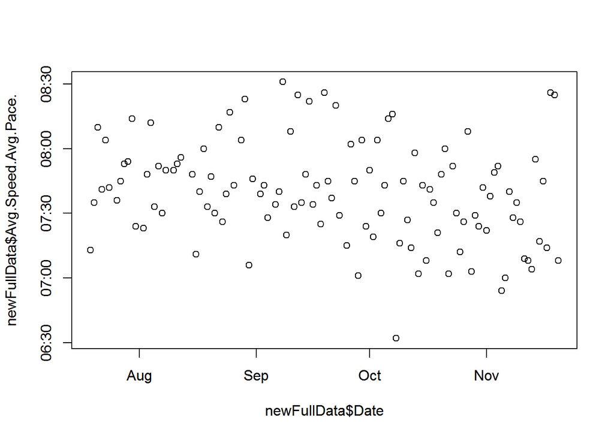

```r
#fix Average Pace
newFullData$Avg.Speed.Avg.Pace. <- as.POSIXct(newFullData$Avg.Speed.Avg.Pace., format = '%M:%S')
plot(newFullData$Date,newFullData$Avg.Speed.Avg.Pace.)
```

```r
newFullData$avgPace <- newFullData$Avg.Speed.Avg.Pace.
newFullData$Avg.Speed.Avg.Pace. <- NULL
```

Now, for **Time**, some values are missing the hour, some have the minutes in the hour place, etc. so I can fix this with a FOR loop in order to find the “incorrect” values and fix each one respectively.

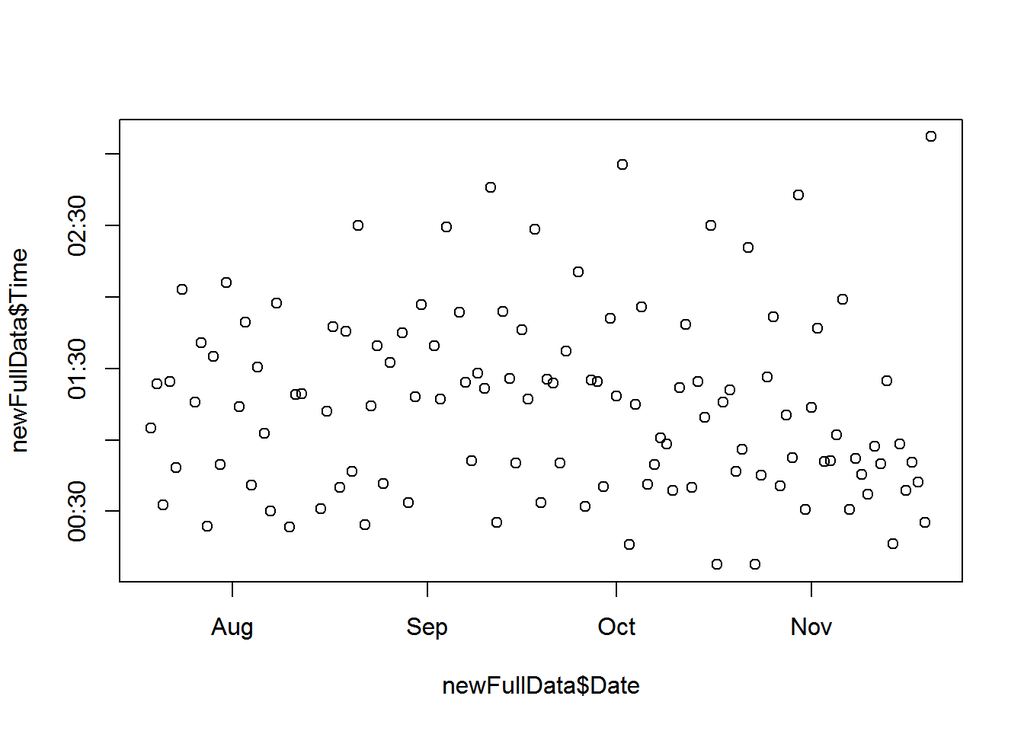

```r
newFullData$Time <- as.character(newFullData$Time)

for (i in 1:nrow(newFullData)) {
  if (nchar(newFullData$Time[i]) == 4) {
    newFullData$Time[i] <- paste("0:0", newFullData$Time[i], sep="")
    #print(paste("00:0", newFullData$Time[i], sep=""))
    #print(newFullData$Time[i])
  } else if (nchar(newFullData$Time[i]) == 8) {
    newFullData$Time[i] <- paste("0:",substring(newFullData$Time[i],1,5), sep="")
    #print(paste("00:",substring(newFullData$Time[i],1,5), sep=""))
  } else if (nchar(newFullData$Time[i]) == 5) {
    newFullData$Time[i] <- paste("0:",newFullData$Time[i], sep="")
    #print(paste("00:",substring(newFullData$Time[i],1,5), sep=""))
  }
}
newFullData$Time <- as.POSIXct(newFullData$Time, format = '%H:%M:%S')

#test plot
plot(newFullData$Date,newFullData$Time)
```

Great. Now the final thing to do is to make sure my **Month** variable is indeed ordered correctly with **factor()**

```r
newFullData$Month <- factor(newFullData$Month, ordered = TRUE, levels = c("Jul","Aug","Sep","Oct","Nov"))
class(newFullData$Month)
```

```
## [1] "ordered" "factor"
```

Now to save this dataset to a file to read into another script so I can do some analysis.

```r
write.csv(newFullData, file = "cleanedMarathonTrainingData.csv", row.names = TRUE)
```